# Презентация по лабораторной работе №1

Операционные системы

Арбатова В. П., НКАбд-01-23

Российский университет дружбы народов, Москва, Россия

27 февраля 2024

## Цель работы

Приобретение практических навыков установки операционной системы на виртуальную машину, настройки минимально необходимых для дальнейшей работы сервисов.

## Задание

1. Установка виртуальной машины
2. Установка операционной системы
3. Настройка виртуальной машины
4. Установка ПО для создания документации
5. Выполнение домашнего задания
6. Ответы на контрольные вопросы

## Выполнение лабораторной работы

## Создание виртуальной машины

VirtualBox был у меня установлен заранее, поэтому просто захожу и нажимаю создать машину. Даю ей нащвание, выбираю расположение, тип ОС, версию

[figure not shown]

Настройка машины 1

## Создание виртуальной машины

Выставляю размер памяти 4096МБ, 4 процессора

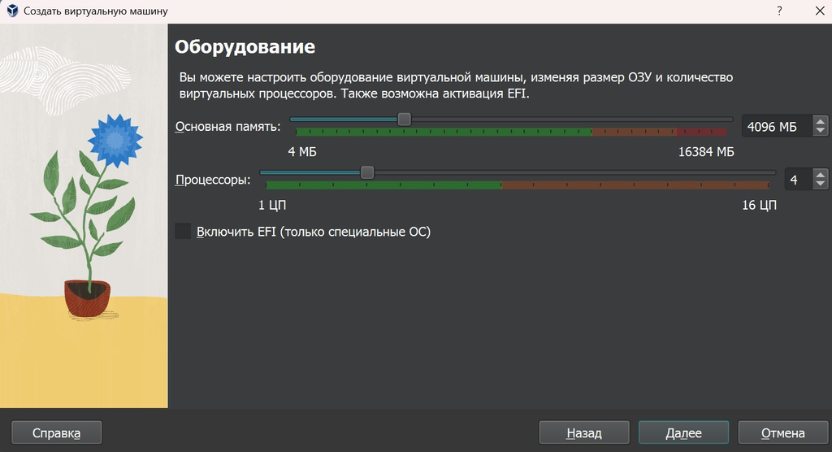

Настройка машины 2

## Создание виртуальной машины

Выставляю размер диска 80 ГБ

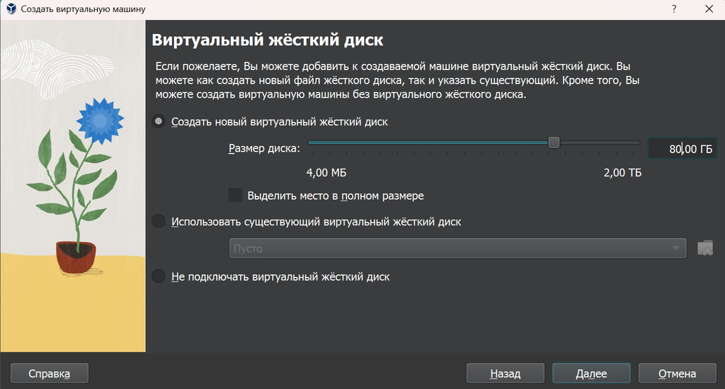

Настройка машины 3

## Создание виртуальной машины

Нажимаю готово. Затем перехожу в настройки машины в раздел Дисплей, включаю 3D-ускорение

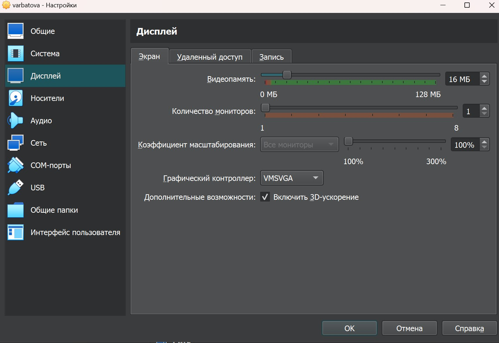

Настройка машины 4

## Создание виртуальной машины

В разделе Носители добавляю образ диска ОС, включаю живой CD/DVD

[figure not shown]

Настройка машины 5

## Установка операционной системы

Запускаю машину, нажимаю win+D, в поиске ввожу liveinst, нажимаю enter

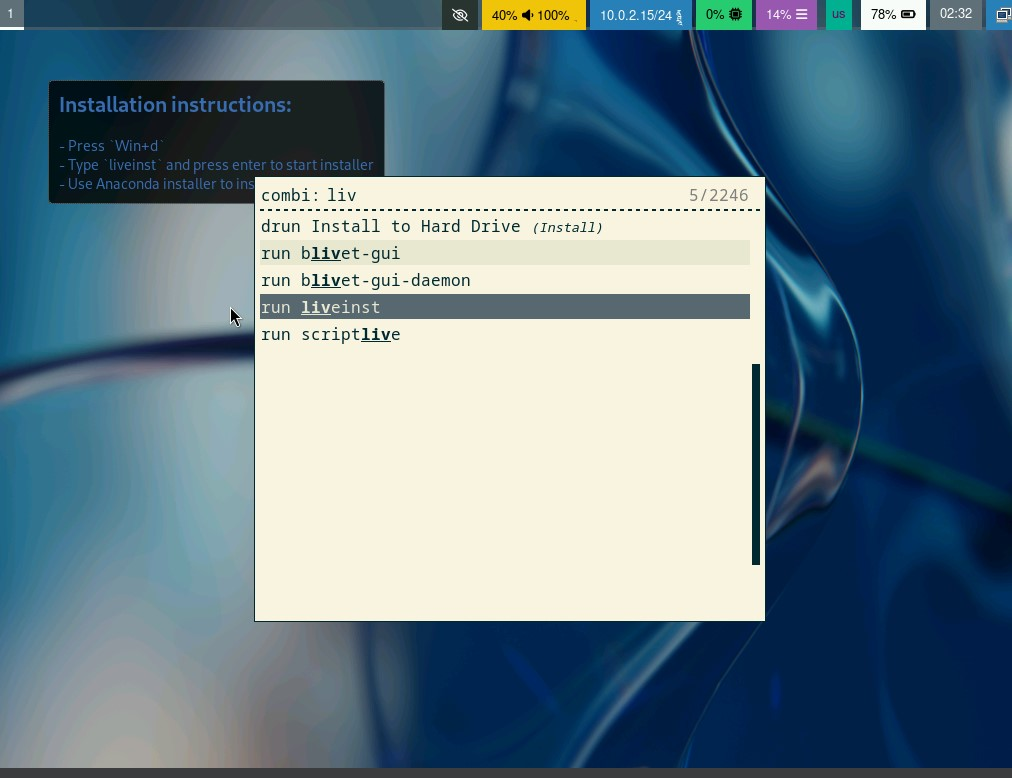

Настройка машины 6

## Установка операционной системы

Начало настройки, выбираю русский язык

[figure not shown]

Выбор языка настройки

## Установка операционной системы

Выбираю раскладки клавиатуры

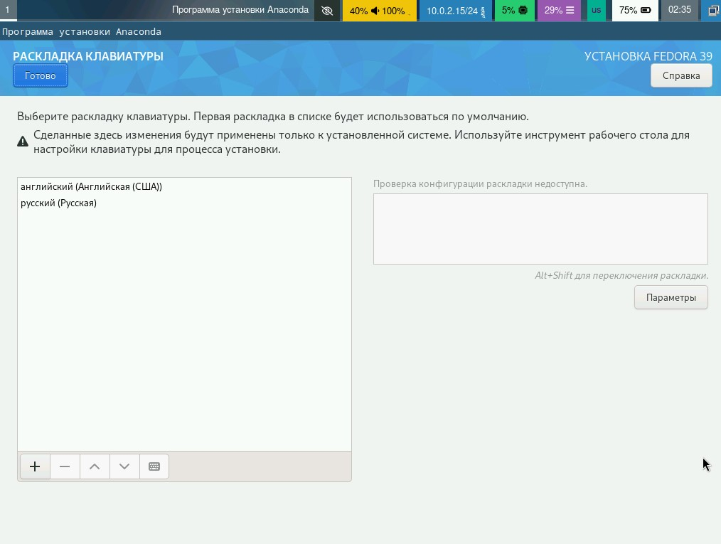

Выбор раскладки клавиатуры

## Установка операционной системы

Выбираю регион

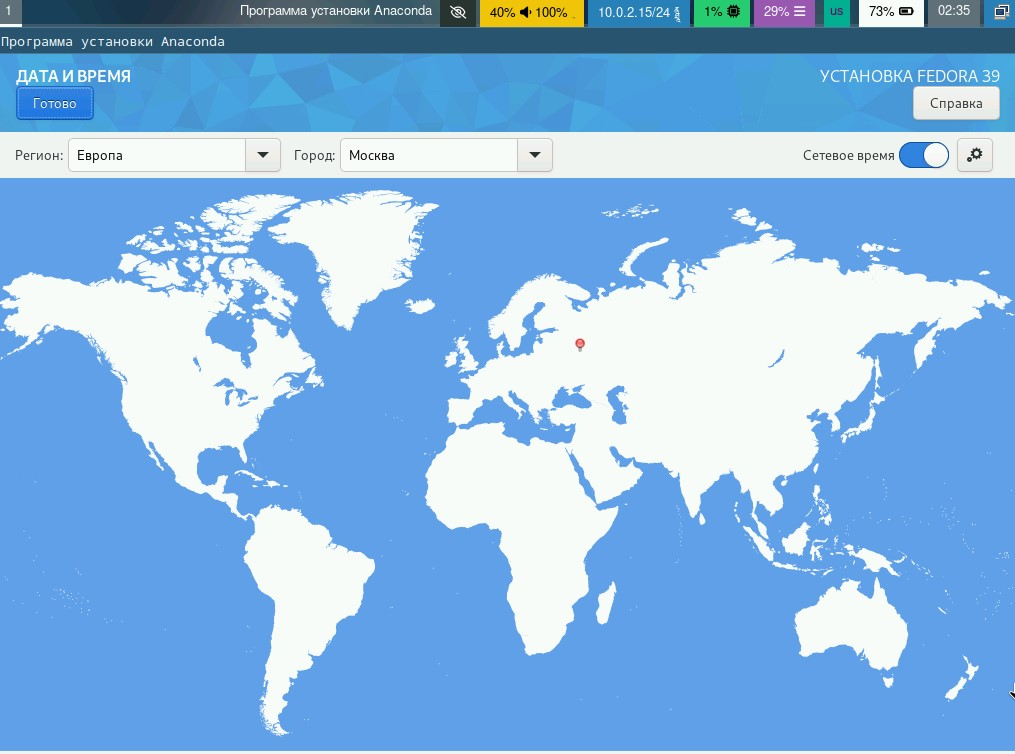

Выбор региона

## Установка операционной системы

Выбираю место установки

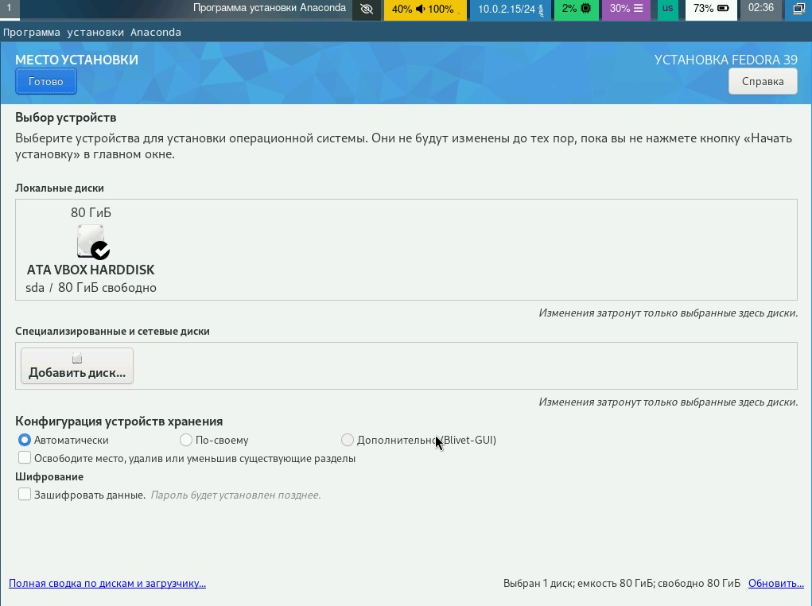

Выбор места установки

## Установка операционной системы

Создаю учётную запись

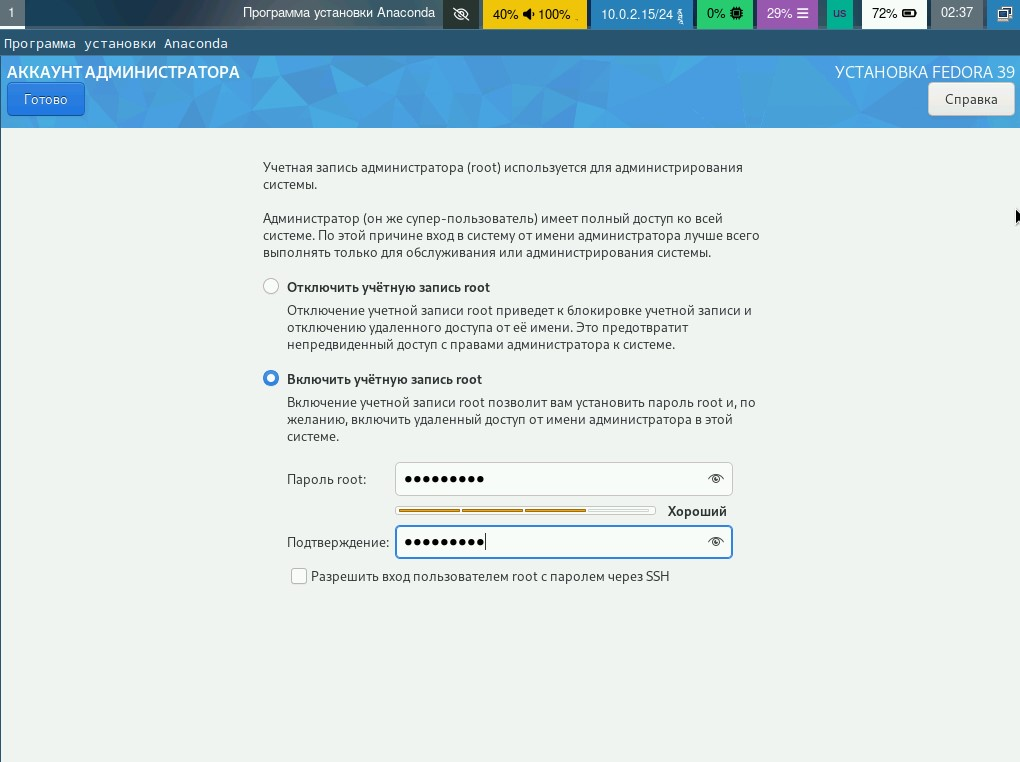

Создание учётной записи

## Установка операционной системы

Создаю пользователя

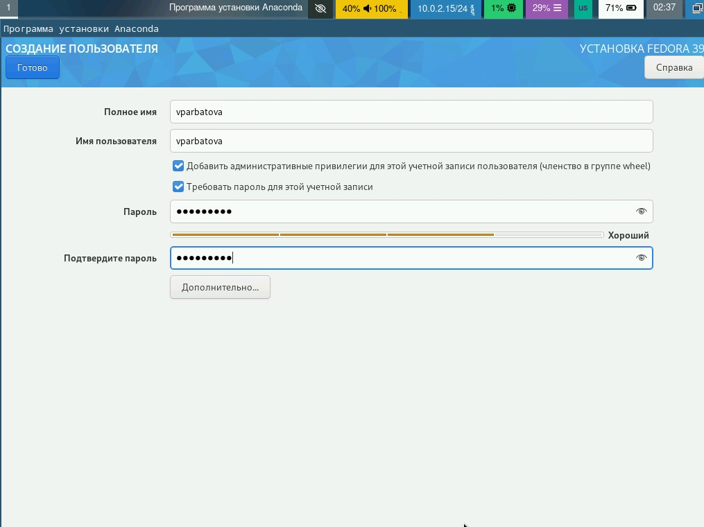

Создание пользователя

## Установка операционной системы

Задаю имя узла в сети

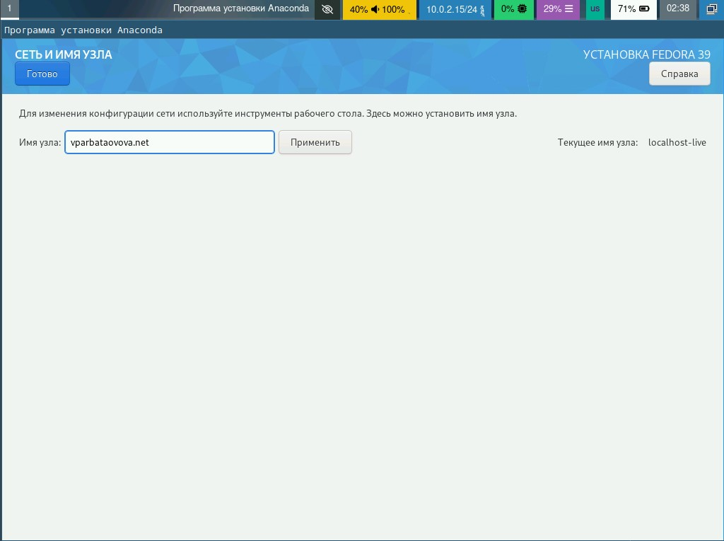

Имя узла

## Установка операционной системы

Выхожу из машины и отключаю носитель

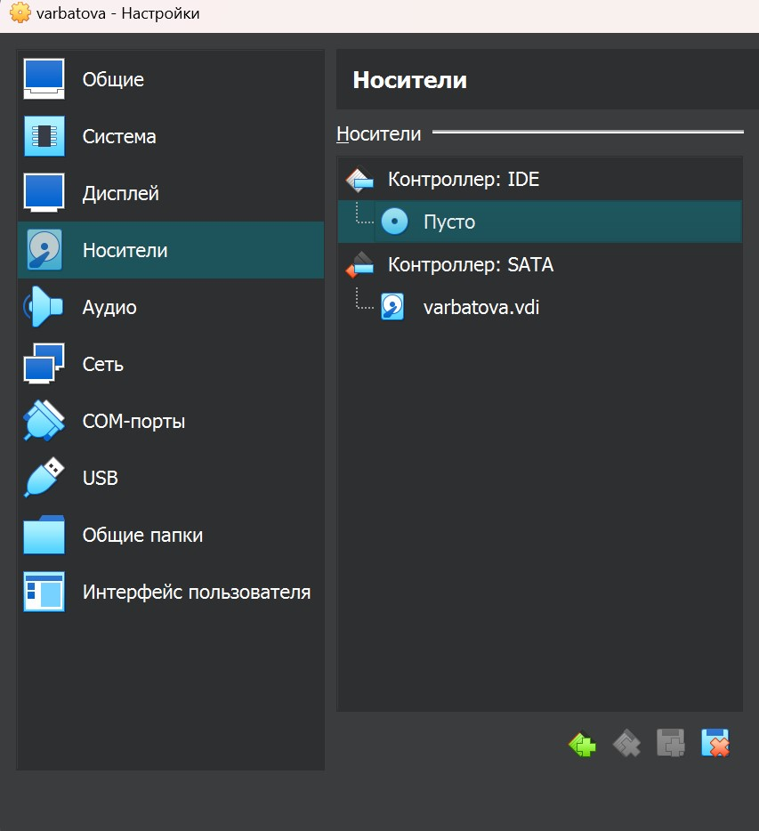

Отключение носителя

## Работа с машиной после настройки

Переключаюсь на режим супер-пользователя

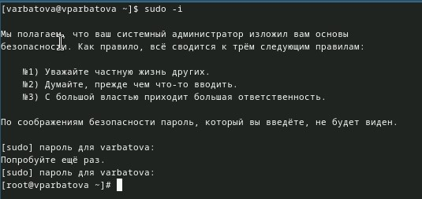

Переход в режим супер-пользователя

## Работа с машиной после настройки

Обновляю все пакеты

## Работа с машиной после настройки

Скачиваю программу для удобства работы в консоли

## Работа с машиной после настройки

Установка программного обеспечения

## Работа с машиной после настройки

Включаю таймер

## Работа с машиной после настройки

В файле /etc/selinux/config заменяю значения

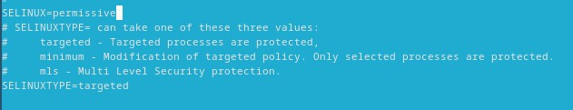

Изменённый файл

## Работа с машиной после настройки

Перезагружаю машину

## Работа с машиной после настройки

Запускаю терминальный мультиплексор tmux

## Работа с машиной после настройки

Перехожу в режим супер-пользователя и скачиваю средства разработки

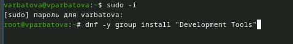

Скачивание средств разработки

## Работа с машиной после настройки

Устанавливаю пакеты DKMS

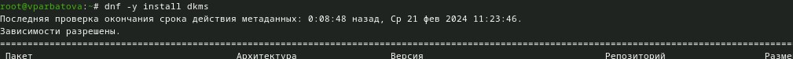

Установка пакетов DKMS

## Работа с машиной после настройки

В настройках виртуальной машины подключаю образ диска дополнительной ОС, затем подмонтирую диск

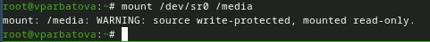

Подмонтирую диск

## Работа с машиной после настройки

Устанавливаю драйвера, затем перезагружаю машину

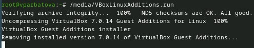

Установка драйверов

## Работа с машиной после настройки

Редактирую конфигурационный файл, перезагружаю машину

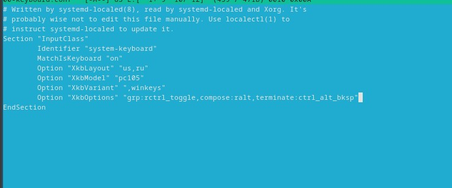

Отредактированный файл

## Установка ПО для создания документации

Скачиваю из репозитория pandoc и pandoc-crosserf

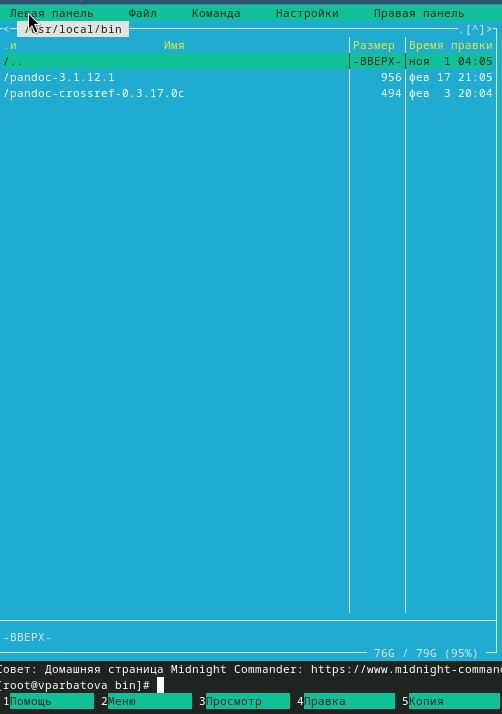

Скаченные файлы

## Установка ПО для создания документации

Устанавливаю Texlive

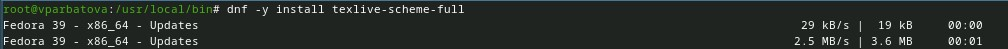

Установка Texlive

## Домашнее задание

Узнаю по очереди версию ядра Linux, частоту процессора (не отображается), модель процессора, объём доступной памяти (не отображается), тип обнаруженного гипервизора

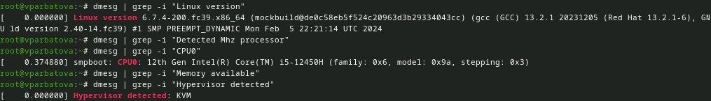

ДЗ1

Узнаю тип файловой системы корневого раздела, затем последовательность монтирования файловых систем

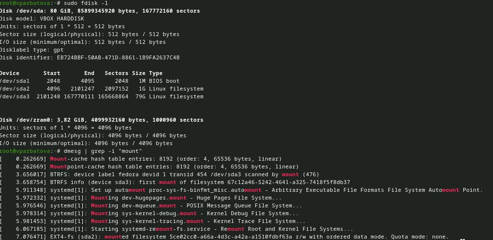

ДЗ2

## Выводы

Я приобрела практические навыки установки операционной системы на виртуальную машину, настройки минимально необходимых для дальнейшей работы сервисов.

# Список литературы